# Lab Assignment Three: Extending Logistic Regression

Team members: Long Zhang,Qinyu Chen, Zhengwen Zhang

# 1 Preparation and Overview

[20 points] Explain the task and what business-case or use-case it is designed to solve (or designed to investigate). Detail exactly what the classification task is and what parties would be interested in the results. For example, would the model be deployed or use mostly for offline analysis?

## 1.1 Business understand and other discussion

The dataset we selected is "mobile price classification" available from kaggle(https://www.kaggle.com/iabhishekofficial/mobile-price-classification),the reason why we did not choose the same dataset from lab one is because it contains binary classification only thus not meeting the requirements for this lab. we tested a few popular datasets from kaggle and finally decided to use this one because of several reasons, first of all, the price range in this dataset varies from 0 to 3,we can do multiple classes prediction based on the price range, on the other hand, this dataset has a high usability(7.1 out of 10), the data contains only numerical data that requires minimal preprocessing, so it is excellent dataset for logistic regression.

## 1.2 Define and prepare your class variables.

[5 points] (mostly the same processes as from previous labs) Define and prepare your class variables. Use proper variable representations (int, float, one-hot, etc.). Use pre-processing methods (as needed) for dimensionality reduction, scaling, etc. Remove variables that are not needed/useful for the analysis. Describe the final dataset that is used for classification/regression (include a description of any newly formed variables you created).

```python
#import the libraries
import os
import pandas as pd
import numpy as np
import seaborn as sns
import matplotlib.pyplot as plt
import scipy
from scipy.special import expit
from scipy.optimize import fmin_bfgs
from sklearn.metrics import accuracy_score
from sklearn.model_selection import ShuffleSplit
from numpy.linalg import pinv
import warnings
warnings.filterwarnings('ignore')

df = pd.read_csv("/Users/chenqinyu/Desktop/mobile.csv")
#df = pd.read_csv("/Users/terrence/Desktop/train.csv")
#df = pd.read_csv(r"C:\Users\tony\Dropbox\smu\CSE7324\assignment\LabThree\train.csv")
```

```python
#preview of the first 5 observations
df.head()
```

|  | battery_power | blue | clock_speed | dual_sim | fc | four_g | int_memory | m_dep | mobile_wt | n_cores | ... | px_height | px_width | ram | sc_h | sc_w | talk_time | three_g | touch_screen | wifi | price_range |
| --- | --- | --- | --- | --- | --- | --- | --- | --- | --- | --- | --- | --- | --- | --- | --- | --- | --- | --- | --- | --- | --- |
| 0 | 842 | 0 | 2.2 | 0 | 1 | 0 | 7 | 0.6 | 188 | 2 | ... | 20 | 756 | 2549 | 9 | 7 | 19 | 0 | 0 | 1 | 1 |
| 1 | 1021 | 1 | 0.5 | 1 | 0 | 1 | 53 | 0.7 | 136 | 3 | ... | 905 | 1988 | 2631 | 17 | 3 | 7 | 1 | 1 | 0 | 2 |
| 2 | 563 | 1 | 0.5 | 1 | 2 | 1 | 41 | 0.9 | 145 | 5 | ... | 1263 | 1716 | 2603 | 11 | 2 | 9 | 1 | 1 | 0 | 2 |
| 3 | 615 | 1 | 2.5 | 0 | 0 | 0 | 10 | 0.8 | 131 | 6 | ... | 1216 | 1786 | 2769 | 16 | 8 | 11 | 1 | 0 | 0 | 2 |
| 4 | 1821 | 1 | 1.2 | 0 | 13 | 1 | 44 | 0.6 | 141 | 2 | ... | 1208 | 1212 | 1411 | 8 | 2 | 15 | 1 | 1 | 0 | 1 |

5 rows × 21 columns

```python
df.describe()
```

|  | battery_power | blue | clock_speed | dual_sim | fc | four_g | int_memory | m_dep | mobile_wt | n_cores | ... | px_height | px_width | ram | sc_h | sc_w | talk_time | three_g | touch_screen | wifi | price_range |
| --- | --- | --- | --- | --- | --- | --- | --- | --- | --- | --- | --- | --- | --- | --- | --- | --- | --- | --- | --- | --- | --- |
| count | 2000.000000 | 2000.0000 | 2000.000000 | 2000.000000 | 2000.000000 | 2000.000000 | 2000.000000 | 2000.000000 | 2000.000000 | 2000.000000 | ... | 2000.000000 | 2000.000000 | 2000.000000 | 2000.000000 | 2000.000000 | 2000.000000 | 2000.000000 | 2000.000000 | 2000.000000 | 2000.000000 |
| mean | 1238.518500 | 0.4950 | 1.522250 | 0.509500 | 4.309500 | 0.521500 | 32.046500 | 0.501750 | 140.249000 | 4.520500 | ... | 645.108000 | 1251.515500 | 2124.213000 | 12.306500 | 5.767000 | 11.011000 | 0.761500 | 0.503000 | 0.507000 | 1.500000 |
| std | 439.418206 | 0.5001 | 0.816004 | 0.500035 | 4.341444 | 0.499662 | 18.145715 | 0.288416 | 35.399655 | 2.287837 | ... | 443.780811 | 432.199447 | 1084.732044 | 4.213245 | 4.356398 | 5.463955 | 0.426273 | 0.500116 | 0.500076 | 1.118314 |
| min | 501.000000 | 0.0000 | 0.500000 | 0.000000 | 0.000000 | 0.000000 | 2.000000 | 0.100000 | 80.000000 | 1.000000 | ... | 0.000000 | 500.000000 | 256.000000 | 5.000000 | 0.000000 | 2.000000 | 0.000000 | 0.000000 | 0.000000 | 0.000000 |
| 25% | 851.750000 | 0.0000 | 0.700000 | 0.000000 | 1.000000 | 0.000000 | 16.000000 | 0.200000 | 109.000000 | 3.000000 | ... | 282.750000 | 874.750000 | 1207.500000 | 9.000000 | 2.000000 | 6.000000 | 1.000000 | 0.000000 | 0.000000 | 0.750000 |
| 50% | 1226.000000 | 0.0000 | 1.500000 | 1.000000 | 3.000000 | 1.000000 | 32.000000 | 0.500000 | 141.000000 | 4.000000 | ... | 564.000000 | 1247.000000 | 2146.500000 | 12.000000 | 5.000000 | 11.000000 | 1.000000 | 1.000000 | 1.000000 | 1.500000 |
| 75% | 1615.250000 | 1.0000 | 2.200000 | 1.000000 | 7.000000 | 1.000000 | 48.000000 | 0.800000 | 170.000000 | 7.000000 | ... | 947.250000 | 1633.000000 | 3064.500000 | 16.000000 | 9.000000 | 16.000000 | 1.000000 | 1.000000 | 1.000000 | 2.250000 |
| max | 1998.000000 | 1.0000 | 3.000000 | 1.000000 | 19.000000 | 1.000000 | 64.000000 | 1.000000 | 200.000000 | 8.000000 | ... | 1960.000000 | 1998.000000 | 3998.000000 | 19.000000 | 18.000000 | 20.000000 | 1.000000 | 1.000000 | 1.000000 | 3.000000 |

8 rows × 21 columns

```python
# creating a data description table
df_des = pd.DataFrame()
df_des['features']=df.columns
df_des['descriptions']=['battery capacity','with bluetooth or not','CPU speed','whether support two sim cards or not','front camera resolution','4G compatibility','storage(GB)','mobile phone depth(cm)','mobile phone width(cm)','number of cores','rear camera resolution','maximum resolution height','maximum resolution width','random access memory','screen height(cm)','screen width(cm)','longest call time after full charging','whether support 3G or not','whether support touch screen or not','whether support WIFI or not','price range[0-3]']
df_des
```

|  | features | descriptions |
| --- | --- | --- |
| 0 | battery_power | battery capacity |
| 1 | blue | with bluetooth or not |
| 2 | clock_speed | CPU speed |
| 3 | dual_sim | whether support two sim cards or not |
| 4 | fc | front camera resolution |
| 5 | four_g | 4G compatibility |
| 6 | int_memory | storage(GB) |
| 7 | m_dep | mobile phone depth(cm) |
| 8 | mobile_wt | mobile phone width(cm) |
| 9 | n_cores | number of cores |
| 10 | pc | rear camera resolution |
| 11 | px_height | maximum resolution height |
| 12 | px_width | maximum resolution width |
| 13 | ram | random access memory |
| 14 | sc_h | screen height(cm) |
| 15 | sc_w | screen width(cm) |
| 16 | talk_time | longest call time after full charging |
| 17 | three_g | whether support 3G or not |
| 18 | touch_screen | whether support touch screen or not |
| 19 | wifi | whether support WIFI or not |
| 20 | price_range | price range[0-3] |

```python
print(df.info())
#data types
```

```
<class 'pandas.core.frame.DataFrame'>
RangeIndex: 2000 entries, 0 to 1999
Data columns (total 21 columns):
battery_power    2000 non-null int64
blue             2000 non-null int64
clock_speed      2000 non-null float64
dual_sim         2000 non-null int64
fc               2000 non-null int64
four_g           2000 non-null int64
int_memory       2000 non-null int64
m_dep            2000 non-null float64
mobile_wt        2000 non-null int64
n_cores          2000 non-null int64
pc               2000 non-null int64
px_height        2000 non-null int64
px_width         2000 non-null int64
ram              2000 non-null int64
sc_h             2000 non-null int64
sc_w             2000 non-null int64
talk_time        2000 non-null int64
three_g          2000 non-null int64
touch_screen     2000 non-null int64
wifi             2000 non-null int64
price_range      2000 non-null int64
dtypes: float64(2), int64(19)
memory usage: 328.2 KB
None
```

There are 2000 rows in the csv file, there are no missing values for these observations, these features are either int64 or float64,so all data are numerical, there is no need to replace categorical data to numerical data.

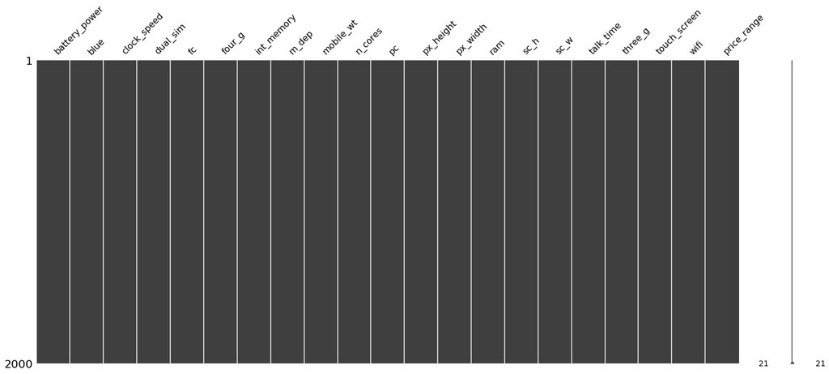

```python
import missingno as mn
mn.matrix(df)
```

The plot above also confirms that no missing data is abserved for this dataset.

```python
# define the dependent variable "price_range"
df["price_range"] = df["price_range"].astype(float)
target =  df['price_range']
target_names='price_range'
y = target.values
```

```python
df = df.drop("price_range",axis=1)#removing target from table,returning a new DataFrame object, the original `df` remains untouched.
```

```python
# do some scaling and prepare the dataset for modeling
from sklearn.preprocessing import StandardScaler
X = df.values
X = StandardScaler().fit(X).transform(X)
```

## 1.3 Training and Testing Split

[5 points] Divide you data into training and testing data using an 80% training and 20% testing split. Use the cross validation modules that are part of scikit-learn. Argue "for" or "against" splitting your data using an 80/20 split. That is, why is the 80/20 split appropriate (or not) for your dataset?

```python
from sklearn.model_selection import train_test_split

X_train, X_test, y_train, y_test = train_test_split(X, y, test_size=0.2)
print(X_train.shape, y_train.shape)
print(X_test.shape, y_test.shape)
```

```
(1600, 20) (1600,)
(400, 20) (400,)
```

### Use the cross validation modules that are part of scikit-learn.

```python
from sklearn.model_selection import ShuffleSplit

# to use the cross validation object in scikit learn, we need to grab an instance
#    of the object and set it up. This object will be able to split our data into
#    training and testing splits
num_cv_iterations = 3
cv_object = ShuffleSplit(n_splits=num_cv_iterations,test_size  = 0.2)

print(cv_object)
```

```
ShuffleSplit(n_splits=3, random_state=None, test_size=0.2, train_size=None)
```

Reference: https://stackoverflow.com/questions/13610074/is-there-a-rule-of-thumb-for-how-to-divide-a-dataset-into-training-and-validation

According to Pareto principle, a 80/20 split of the dataset into training(80%) and testing(20%) is very popular in machine learning, there is a reason for that: depending on the total number of observations, absolute number of training data(80%) can be very small, for example, if you have only 100 or less instances, there will be 80 or less training data, the parameters obtained from training data will have big variation, the model will not accurately predict the testing results. However, if the dataset size is very big,for example, 10,000, then a 80:20 or 90:10 does not matter, since either split will give you small variance for the model, the only thing you need to consider at this time is to use less data to avoid excessive computation.

# 2 Modeling

The implementation of logistic regression must be written only from the examples given to you by the instructor. No credit will be assigned to teams that copy implementations from another source, regardless of if the code is properly cited.

[20 points] Create a custom, one-versus-all logistic regression classifier using numpy and scipy to optimize. Use object oriented conventions identical to scikit-learn. You should start with the template developed by the instructor in the course. You should add the following functionality to the logistic regression classifier:

1) Ability to choose optimization technique when class is instantiated: either steepest descent, stochastic gradient descent, or Newton's method.

2) Update the gradient calculation to include a customizable regularization term (either using no regularization, L1 regularization, L2 regularization, or both L1 and L2 regularization). Associate a cost with the regularization term, "C", that can be adjusted when the class is instantiated.

## 2.1 Steepest descent, Stochastic gradient descent, and Newton's method

When we use steepest descent, stochastic gradient descent, we update the gradient calculation by three senarios:

1) L1 regularization

2) L2 regularization

3) Both L1 regularization and L2 regularization

There are two ways for Newton's method, Hessian and BFGS.Because Hession has some problems(cited from the instructor's ML notebooks):

1) Highly dependent on starting point

2) Jumps can get really random

3) Near saddle points, inverse hessian unstable

4) Hessian not always invertible or invertible with correct numerical precision

We chose BFGS here to finish Newton's method. we set the initial values of C1 and C2 equal to 0.001.

Starting with the template developed by the instructor in the course

```python
#codes cite from our class codes:https://github.com/eclarson/MachineLearningNotebooks/blob/master/06.%20Optimization.ipynb
from scipy.optimize import fmin_bfgs
# from last time, our logistic regression algorithm is given by (including everything we previously had):
class L1Regularization:
    def __init__(self, eta, iterations=100, C1=0.001, method='steepest'):
        self.eta = eta
        self.iters = iterations
        self.C = C1
        self.method = method
        # internally we will store the weights as self.w_ to keep with sklearn conventions

    def __str__(self):
        if(hasattr(self,'w_')):
            return 'Binary Logistic Regression Object with coefficients:\n'+ str(self.w_) # is we have trained the object
        else:
            return 'Untrained Binary Logistic Regression Object'

    # convenience, private:
    @staticmethod
    def _add_bias(X):
        return np.hstack((np.ones((X.shape[0],1)),X)) # add bias term

    @staticmethod
    def _sigmoid(theta):
        # increase stability, redefine sigmoid operation
        return expit(theta) #1/(1+np.exp(-theta))

    @staticmethod
    def _sgn(w):
        if w>0:
            return 1
        elif w<0:
            return -1
        else:
            return 0

    @staticmethod
    def objective_function(w,X,y,C1):
        g = expit(X @ w)
        return -np.sum(np.log(g[y==1]))-np.sum(np.log(1-g[y==0])) + C1*sum(w**2) #-np.sum(y*np.log(g)+(1-y)*np.log(1-g))

    @staticmethod
    def objective_gradient(w,X,y,C1):
        g = expit(X @ w)
        ydiff = y-g # get y difference
        gradient = np.mean(X * ydiff[:,np.newaxis], axis=0)
        gradient = gradient.reshape(w.shape)
        gradient[1:] += -2 * w[1:] * C1
        return -gradient

        #steepest descent
    def _steepest_descent_get_gradient(self,X,y):
        ydiff = y-self.predict_proba(X,add_bias=False).ravel() # get y difference
        gradient = np.mean(X * ydiff[:,np.newaxis], axis=0) # make ydiff a column vector and multiply through
        gradient = gradient.reshape(self.w_.shape)

        # using both L1 and L2 regularization
        sgn_v = np.vectorize(self._sgn)
        # new gradient update method
        gradient[1:] += -2 * self.w_[1:] * self.C
        return gradient

        # stochastic gradient calculation
    def _stochastic_gradient_get_gradient(self,X,y):
        idx = int(np.random.rand()*len(y)) # grab random instance
        ydiff = y[idx]-self.predict_proba(X[idx],add_bias=False) # get y difference (now scalar)
        gradient = X[idx] * ydiff[:,np.newaxis] # make ydiff a column vector and multiply through
        gradient = gradient.reshape(self.w_.shape)

        # using L1 regularization
        sgn_v = np.vectorize(self._sgn)
        # new gradient update method
        gradient[1:] += -2 * self.w_[1:] * self.C
        return gradient

    # public:
    def predict_proba(self,X,add_bias=True):
        # add bias term if requested
        Xb = self._add_bias(X) if add_bias else X
        return self._sigmoid(Xb @ self.w_) # return the probability y=1

    def predict(self,X):
        return (self.predict_proba(X)>0.5) #return the actual prediction

    def fit(self, X, y):
        Xb = self._add_bias(X) # add bias term
        num_samples, num_features = Xb.shape

        self.w_ = np.zeros((num_features,1)) # init weight vector to zeros

        # for as many as the max iterations
        # choose differt gradient caculation function
        for _ in range(self.iters):
            if self.method =='steepest':
                gradient = self._steepest_descent_get_gradient(Xb,y)

            if self.method =='stochastic':
                gradient = self._stochastic_gradient_get_gradient(Xb,y)

            if self.method =='newton':
                self.w_ = fmin_bfgs(self.objective_function, # what to optimize
                            np.zeros((num_features,1)), # starting point
                            fprime=self.objective_gradient, # gradient function
                            args=(Xb,y,self.C), # extra args for gradient and objective function
                            gtol=1e-03, # stopping criteria for gradient, |v_k|
                            maxiter=self.iters, # stopping criteria iterations
                            disp=False)

                self.w_ = self.w_.reshape((num_features,1))
                continue

            self.w_ += gradient*self.eta # multiply by learning rate
```

```python
blr = L1Regularization(eta=0.1,iterations=100,C1=0.01)
blr.fit(X,y)
yhat = blr.predict(X)
print('Using steepest descent:\nAccuracy of:',accuracy_score(y,yhat),'\n')
sd1 = accuracy_score(y,yhat)

blr = L1Regularization(eta=0.1,iterations=100,C1=0.01,method='stochastic')
blr.fit(X,y)
yhat = blr.predict(X)
print('Using stochastic gradient descent:\nAccuracy of:',accuracy_score(y,yhat),'\n')
sgd1=accuracy_score(y,yhat)


blr = L1Regularization(_,iterations=100,C1=0.01,method='newton')
blr.fit(X,y)
yhat = blr.predict(X)
print('Using Newton\'s method:\nAccuracy of:',accuracy_score(y,yhat),'\n')
nt1=accuracy_score(y,yhat)
```

```
Using steepest descent:
Accuracy of: 0.4555

Using stochastic gradient descent:
Accuracy of: 0.3635

Using Newton's method:
Accuracy of: 0.467
```

```python
#Starting with the template developed by the instructor in the course
from scipy.optimize import fmin_bfgs
# from last time, our logistic regression algorithm is given by (including everything we previously had):
class L2Regularization:
    def __init__(self, eta, iterations=100,C2=0.001, method='steepest'):
        self.eta = eta
        self.iters = iterations
        self.C = C2
        self.method = method
        # internally we will store the weights as self.w_ to keep with sklearn conventions

    def __str__(self):
        if(hasattr(self,'w_')):
            return 'Binary Logistic Regression Object with coefficients:\n'+ str(self.w_) # is we have trained the object
        else:
            return 'Untrained Binary Logistic Regression Object'

    # convenience, private:
    @staticmethod
    def _add_bias(X):
        return np.hstack((np.ones((X.shape[0],1)),X)) # add bias term

    @staticmethod
    def _sigmoid(theta):
        # increase stability, redefine sigmoid operation
        return expit(theta) #1/(1+np.exp(-theta))

    @staticmethod
    def _sgn(w):
        if w>0:
            return 1
        elif w<0:
            return -1
        else:
            return 0

    @staticmethod
    def objective_function(w,X,y,C2):
        g = expit(X @ w)
        return -np.sum(np.log(g[y==1]))-np.sum(np.log(1-g[y==0])) + C2*sum(w**2) #-np.sum(y*np.log(g)+(1-y)*np.log(1-g))

    @staticmethod
    def objective_gradient(w,X,y,C2):
        g = expit(X @ w)
        ydiff = y-g # get y difference
        gradient = np.mean(X * ydiff[:,np.newaxis], axis=0)
        gradient = gradient.reshape(w.shape)
        gradient[1:] += -2 * w[1:] * C2
        return -gradient

        #steepest descent
    def _steepest_descent_get_gradient(self,X,y):
        ydiff = y-self.predict_proba(X,add_bias=False).ravel() # get y difference
        gradient = np.mean(X * ydiff[:,np.newaxis], axis=0) # make ydiff a column vector and multiply through
        gradient = gradient.reshape(self.w_.shape)

        # using L2 regularization
        sgn_v = np.vectorize(self._sgn)
        # new gradient update method
        gradient[1:] += - self.C * sgn_v(self.w_[1:])
        return gradient

        # stochastic gradient calculation
    def _stochastic_gradient_get_gradient(self,X,y):
        idx = int(np.random.rand()*len(y)) # grab random instance
        ydiff = y[idx]-self.predict_proba(X[idx],add_bias=False) # get y difference (now scalar)
        gradient = X[idx] * ydiff[:,np.newaxis] # make ydiff a column vector and multiply through
        gradient = gradient.reshape(self.w_.shape)

        # using both L1 and L2 regularization
        sgn_v = np.vectorize(self._sgn)
        # new gradient update method
        gradient[1:] += - self.C * sgn_v(self.w_[1:])
        return gradient

    # public:
    def predict_proba(self,X,add_bias=True):
        # add bias term if requested
        Xb = self._add_bias(X) if add_bias else X
        return self._sigmoid(Xb @ self.w_) # return the probability y=1

    def predict(self,X):
        return (self.predict_proba(X)>0.5) #return the actual prediction

    def fit(self, X, y):
        Xb = self._add_bias(X) # add bias term
        num_samples, num_features = Xb.shape

        self.w_ = np.zeros((num_features,1)) # init weight vector to zeros

        # for as many as the max iterations
        # choose differt gradient caculation function
        for _ in range(self.iters):
            if self.method =='steepest':
                gradient = self._steepest_descent_get_gradient(Xb,y)

            if self.method =='stochastic':
                gradient = self._stochastic_gradient_get_gradient(Xb,y)

            if self.method =='newton':
                self.w_ = fmin_bfgs(self.objective_function, # what to optimize
                            np.zeros((num_features,1)), # starting point
                            fprime=self.objective_gradient, # gradient function
                            args=(Xb,y,self.C), # extra args for gradient and objective function
                            gtol=1e-03, # stopping criteria for gradient, |v_k|
                            maxiter=self.iters, # stopping criteria iterations
                            disp=False)

                self.w_ = self.w_.reshape((num_features,1))
                continue

            self.w_ += gradient*self.eta # multiply by learning rate
```

```python
blr = L2Regularization(eta=0.1,iterations=100,C2=0.01)
blr.fit(X,y)
yhat = blr.predict(X)
print('Using steepest descent:\nAccuracy of:',accuracy_score(y,yhat),'\n')
sd2 = accuracy_score(y,yhat)

blr = L2Regularization(eta=0.1,iterations=100,C2=0.01,method='stochastic')
blr.fit(X,y)
yhat = blr.predict(X)
print('Using stochastic gradient descent:\nAccuracy of:',accuracy_score(y,yhat),'\n')
sgd2 = accuracy_score(y,yhat)
blr = L2Regularization(_,iterations=100,C2=0.01,method='newton')
blr.fit(X,y)
yhat = blr.predict(X)
print('Using Newton\'s method:\nAccuracy of:',accuracy_score(y,yhat),'\n')
nt2 = accuracy_score(y,yhat)
```

```
Using steepest descent:
Accuracy of: 0.4735

Using stochastic gradient descent:
Accuracy of: 0.387

Using Newton's method:
Accuracy of: 0.467
```

### Senario #3: L1 regularization and L2 regularization

```python
#Starting with the template developed by the instructor in the course
from scipy.optimize import fmin_bfgs
# from last time, our logistic regression algorithm is given by (including everything we previously had):
class L1L2Regularization:
    def __init__(self, eta, iterations=100, C1=0.001,C2=0.001, method='steepest'):
        self.eta = eta
        self.iters = iterations
        self.C1 = C1
        self.C2 = C2
        self.method = method
        # internally we will store the weights as self.w_ to keep with sklearn conventions

    def __str__(self):
        if(hasattr(self,'w_')):
            return 'Binary Logistic Regression Object with coefficients:\n'+ str(self.w_) # is we have trained the object
        else:
            return 'Untrained Binary Logistic Regression Object'

    # convenience, private:
    @staticmethod
    def _add_bias(X):
        return np.hstack((np.ones((X.shape[0],1)),X)) # add bias term

    @staticmethod
    def _sigmoid(theta):
        # increase stability, redefine sigmoid operation
        return expit(theta) #1/(1+np.exp(-theta))

    @staticmethod
    def _sgn(w):
        if w>0:
            return 1
        elif w<0:
            return -1
        else:
            return 0

    @staticmethod
    def objective_function(w,X,y,C1):
        g = expit(X @ w)
        return -np.sum(np.log(g[y==1]))-np.sum(np.log(1-g[y==0])) + C1*sum(w**2) #-np.sum(y*np.log(g)+(1-y)*np.log(1-g))

    @staticmethod
    def objective_gradient(w,X,y,C1):
        g = expit(X @ w)
        ydiff = y-g # get y difference
        gradient = np.mean(X * ydiff[:,np.newaxis], axis=0)
        gradient = gradient.reshape(w.shape)
        gradient[1:] += -2 * w[1:] * C1
        return -gradient

        #steepest descent
    def _steepest_descent_get_gradient(self,X,y):
        ydiff = y-self.predict_proba(X,add_bias=False).ravel() # get y difference
        gradient = np.mean(X * ydiff[:,np.newaxis], axis=0) # make ydiff a column vector and multiply through
        gradient = gradient.reshape(self.w_.shape)

        # using both L1 and L2 regularization
        sgn_v = np.vectorize(self._sgn)
        # new gradient update method
        gradient[1:] += -2 * self.w_[1:] * self.C1 - self.C2 * sgn_v(self.w_[1:])
        return gradient

        # stochastic gradient calculation
    def _stochastic_gradient_get_gradient(self,X,y):
        idx = int(np.random.rand()*len(y)) # grab random instance
        ydiff = y[idx]-self.predict_proba(X[idx],add_bias=False) # get y difference (now scalar)
        gradient = X[idx] * ydiff[:,np.newaxis] # make ydiff a column vector and multiply through
        gradient = gradient.reshape(self.w_.shape)

        # using both L1 and L2 regularization
        sgn_v = np.vectorize(self._sgn)
        # new gradient update method
        gradient[1:] += -2 * self.w_[1:] * self.C1 - self.C2 * sgn_v(self.w_[1:])
        return gradient

    # public:
    def predict_proba(self,X,add_bias=True):
        # add bias term if requested
        Xb = self._add_bias(X) if add_bias else X
        return self._sigmoid(Xb @ self.w_) # return the probability y=1

    def predict(self,X):
        return (self.predict_proba(X)>0.5) #return the actual prediction

    def fit(self, X, y):
        Xb = self._add_bias(X) # add bias term
        num_samples, num_features = Xb.shape

        self.w_ = np.zeros((num_features,1)) # init weight vector to zeros

        # for as many as the max iterations
        # choose differt gradient caculation function
        for _ in range(self.iters):
            if self.method =='steepest':
                gradient = self._steepest_descent_get_gradient(Xb,y)

            if self.method =='stochastic':
                gradient = self._stochastic_gradient_get_gradient(Xb,y)

            if self.method =='newton':
                self.w_ = fmin_bfgs(self.objective_function, # what to optimize
                            np.zeros((num_features,1)), # starting point
                            fprime=self.objective_gradient, # gradient function
                            args=(Xb,y,self.C1), # extra args for gradient and objective function
                            gtol=1e-03, # stopping criteria for gradient, |v_k|
                            maxiter=self.iters, # stopping criteria iterations
                            disp=False)

                self.w_ = self.w_.reshape((num_features,1))
                continue

            self.w_ += gradient*self.eta # multiply by learning rate
```

```python
blr = L1L2Regularization(eta=0.1,iterations=100,C1=0.01,C2=0.01)
blr.fit(X,y)
yhat = blr.predict(X)
print('Using steepest descent:\nAccuracy of:',accuracy_score(y,yhat),'\n')
sd12 = accuracy_score(y,yhat)


blr = L1L2Regularization(eta=0.1,iterations=100,C1=0.01,C2=0.01,method='stochastic')
blr.fit(X,y)
yhat = blr.predict(X)
print('Using stochastic gradient descent:\nAccuracy of:',accuracy_score(y,yhat),'\n')
sgd12 = accuracy_score(y,yhat)
blr = L1L2Regularization(_,iterations=100,C1=0.01,C2=0.01,method='newton')
blr.fit(X,y)
yhat = blr.predict(X)
print('Using Newton\'s method:\nAccuracy of:',accuracy_score(y,yhat),'\n')
nt12 = accuracy_score(y,yhat)
```

```
Using steepest descent:
Accuracy of: 0.458

Using stochastic gradient descent:
Accuracy of: 0.411

Using Newton's method:
Accuracy of: 0.467
```

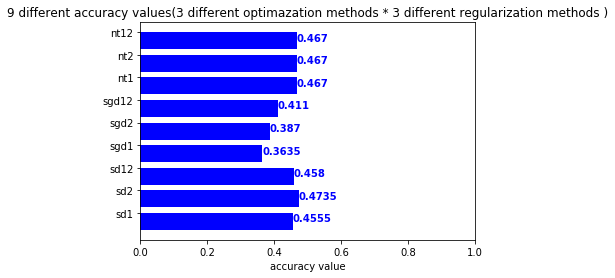

```python
import os
import numpy as np
import matplotlib.pyplot as plt

x = [u'sd1', u'sd2', u'sd12', u'sgd1', u'sgd2', u'sgd12', u'nt1', u'nt2',u'nt12']
y = [sd1,sd2,sd12,sgd1,sgd2,sgd12,nt1,nt2,nt12]

fig, ax = plt.subplots()
width = 0.75 # the width of the bars
ind = np.arange(len(y))  # the x locations for the groups
ax.barh(ind, y, width, color="blue")
ax.set_yticks(ind+width/2)
ax.set_yticklabels(x, minor=False)

plt.title('9 different accuracy values(3 different optimazation methods * 3 different regularization methods )')
plt.xlabel('accuracy value')
#plt.show()
plt.savefig(os.path.join('test.png'), dpi=300, format='png', bbox_inches='tight') # use format='svg' or 'pdf' for vectorial pictures

# for i, v in enumerate(y):
#     ax.text(v + 3, i + .25, str(v), color='blue', fontweight='bold')
plt.xlim(0,1)

for i, v in enumerate(y):
    ax.text(v , i, str(v), color='blue', fontweight='bold')
```

From the above bar chart plot, we could tell that all the three methods have accuracy <50%:

1. the newton accuracy values are consistent for the three regularization
2. the stochastic gradient descent methods have lowest accuracy of all the three methods
3. the steepest descent method is close to the performance of newton method overall, there are some variations for different regulations.

```python
class LogisticRegression:
    def __init__(self, eta, iterations=500,C2=0.001, method='steepest'):
        self.eta = eta
        self.iters = iterations
        self.C2 = C2
        self.method = method
        # internally we will store the weights as self.w_ to keep with sklearn conventions

    def __str__(self):
        if(hasattr(self,'w_')):
            return 'MultiClass Logistic Regression Object with coefficients:\n'+ str(self.w_)
        else:
            return 'Untrained MultiClass Logistic Regression Object'

    def fit(self,X,y):
        num_samples, num_features = X.shape
        self.unique_ = np.unique(y) # get each unique class value
        num_unique_classes = len(self.unique_)
        self.classifiers_ = [] # will fill this array with binary classifiers
#         print(self.unique_)
        for i,yval in enumerate(self.unique_): # for each unique value
            y_binary = y==yval # create a binary problem
            # train the binary classifier for this class
            blr = L2Regularization(self.eta, self.iters, self.C2, self.method)
            blr.fit(X,y_binary)
            # add the trained classifier to the list
            self.classifiers_.append(blr)

        # save all the weights into one matrix, separate column for each class
        self.w_ = np.hstack([x.w_ for x in self.classifiers_]).T

    def predict_proba(self,X):
        probs = []
        for blr in self.classifiers_:
            probs.append(blr.predict_proba(X)) # get probability for each classifier

        return np.hstack(probs) # make into single matrix

    def predict(self,X):
        return np.argmax(self.predict_proba(X),axis=1) # take argmax along row
```

```python
%%time

lr = LogisticRegression(eta=0.1,iterations=10000,C2=0.001)
lr.fit(X_train,y_train)
# print(lr)

yhat = lr.predict(X_train)
print('Accuracy of Training dataset: ',accuracy_score(y_train,yhat))

yhat_test=lr.predict(X_test)
print('Accuracy of Test dataset: ',accuracy_score(y_test,yhat_test))
```

```
Accuracy of Training dataset:  0.860625
Accuracy of Test dataset:  0.865
CPU times: user 30.5 s, sys: 283 ms, total: 30.7 s
Wall time: 7.78 s
```

## 2.2 Train your classifier to achieve good generalization performance.

[15 points] Train your classifier to achieve good generalization performance. That is, adjust the optimization technique and the value of the regularization term "C" to achieve the best performance on your test set. Visualize the performance of the classifier versus the parameters you investigated. Is your method of selecting parameters justified? That is, do you think there is any "data snooping" involved with this method of selecting parameters?

input the X and y again.

```python
df = pd.read_csv("/Users/chenqinyu/Desktop/mobile.csv")
#df = pd.read_csv("/Users/terrence/Desktop/train.csv")
#df = pd.read_csv(r"C:\Users\tony\Dropbox\smu\CSE7324\assignment\LabThree\train.csv")

df["price_range"] = df["price_range"].astype(float)
target =  df['price_range']
target_names='price_range'
y = target.values
df = df.drop("price_range",axis=1)

from sklearn.preprocessing import StandardScaler
X = df.values
X = StandardScaler().fit(X).transform(X)

from sklearn.model_selection import train_test_split

X_train, X_test, y_train, y_test = train_test_split(X, y, test_size=0.2)
print(X_train.shape, y_train.shape)
print(X_test.shape, y_test.shape)
```

```
(1600, 20) (1600,)
(400, 20) (400,)
```

```python
num_cv_iterations = 3
num_instances = len(y)
cv_object = ShuffleSplit(
                         n_splits=num_cv_iterations,
                         test_size  = 0.2)

print(cv_object)
```

```
ShuffleSplit(n_splits=3, random_state=None, test_size=0.2, train_size=None)
```

```python
# run logistic regression and vary some parameters
from sklearn import metrics as mt

# first we create a reusable logisitic regression object
#   here we can setup the object with different learning parameters and constants
lr_clf = LogisticRegression(eta=0.1,iterations=100,C2=0.001) # get object

# now we can use the cv_object that we setup before to iterate through the
#    different training and testing sets. Each time we will reuse the logisitic regression
#    object, but it gets trained on different data each time we use it.

iter_num=0
```

```python
for iter_num, (train_indices, test_indices) in enumerate(cv_object.split(X,y)):
    lr_clf.fit(X[train_indices],y[train_indices])  # train object
    y_hat = lr_clf.predict(X[test_indices]) # get test set precitions

    # print the accuracy and confusion matrix
    print("====Iteration",iter_num," ====")
    print("accuracy", mt.accuracy_score(y[test_indices],y_hat))
    print("confusion matrix\n",mt.confusion_matrix(y[test_indices],y_hat))
```

```
====Iteration 0  ====
accuracy 0.655
confusion matrix
 [[94  0  0  0]
 [56 38 12  2]
 [ 0  4 35 62]
 [ 0  0  2 95]]
====Iteration 1  ====
accuracy 0.575
confusion matrix
 [[92  1  0  0]
 [70 24  8  3]
 [ 1  6 27 81]
 [ 0  0  0 87]]
====Iteration 2  ====
accuracy 0.615
confusion matrix
 [[ 90   0   0   0]
 [ 76  17   9   1]
 [  0  10  30  58]
 [  0   0   0 109]]
```

Exhaustive search for C, then visualize with Boxplots,the following code is referenced from the ML notebook from instructor

```python
%%time

# alternatively, we can also graph out the values using boxplots
num_cv_iterations = 20
num_instances = len(y)
cv_object = ShuffleSplit(n_splits=num_cv_iterations,
                         test_size  = 0.5)

def lr_explor(cost):
    lr_clf = LogisticRegression(eta=0.1,iterations=100,
                                            C2=float(cost)) # get object
    acc = []
    for iter_num, (train_indices, test_indices) in enumerate(cv_object.split(X,y)):
        lr_clf.fit(X[train_indices],y[train_indices])  # train object
        y_hat = lr_clf.predict(X[test_indices]) # get test set predictions
        acc.append(mt.accuracy_score(y[test_indices],y_hat))

    acc = np.array(acc)
    return acc

costs = np.logspace(-5,1,20)
accs = []
for c2 in costs:
    accs.append(lr_explor(c2))
```

```
CPU times: user 1min 34s, sys: 735 ms, total: 1min 34s
Wall time: 23.9 s
```

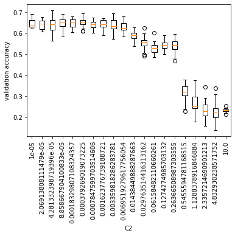

```python
# now show a boxplot of the data across c
plt.boxplot(accs)
plt.xticks(range(1,len(costs)+1),costs,rotation='vertical')
plt.xlabel('C2')
plt.ylabel('validation accuracy')
plt.show()
```

### Data snooping

From wikipedia: data dredging (also data fishing, data snooping, data butchery, and p-hacking) is the misuse of data analysis to find patterns in data that can be presented as statistically significant, thus dramatically increasing and understating the risk of false positives. This is done by performing many statistical tests on the data and only reporting those that come back with significant results.https://en.wikipedia.org/wiki/Data_dredging

From the explaination, we make a conclusion that sometimes the data we use has particularity, but no generality. It means the data(train and test) we divided is suitable for our method. Therefore, we want to try different train and test to find if data snooping happen

```python
%%time

lr = LogisticRegression(eta=0.1,iterations=10000,C2=1e-05)
lr.fit(X_train,y_train)
# print(lr)

yhat = lr.predict(X_train)
print('Accuracy of Training dataset: ',accuracy_score(y_train,yhat))

yhat_test=lr.predict(X_test)
print('Accuracy of Test dataset: ',accuracy_score(y_test,yhat_test))
best=accuracy_score(y_test,yhat_test)
```

```
Accuracy of Training dataset:  0.858125
Accuracy of Test dataset:  0.81
CPU times: user 27 s, sys: 141 ms, total: 27.2 s
Wall time: 6.82 s
```

in order to find if our method has data snooping, we make new train and test dataset for verify data snooping. Here we divided our data 70%train and 30%test to find generality of our method.

```python
df = pd.read_csv("/Users/chenqinyu/Desktop/mobile.csv")
#df = pd.read_csv("/Users/terrence/Desktop/train.csv")
#df = pd.read_csv(r"C:\Users\tony\Dropbox\smu\CSE7324\assignment\LabThree\train.csv")

df["price_range"] = df["price_range"].astype(float)
target =  df['price_range']
target_names='price_range'
y = target.values
df = df.drop("price_range",axis=1)

from sklearn.preprocessing import StandardScaler
X = df.values
X = StandardScaler().fit(X).transform(X)

from sklearn.model_selection import train_test_split

X_train_snoop, X_test_snoop, y_train_snoop, y_test_snoop = train_test_split(X, y, test_size=0.3)
print(X_train_snoop.shape, y_train_snoop.shape)
print(X_test_snoop.shape, y_test_snoop.shape)
```

```
(1400, 20) (1400,)
(600, 20) (600,)
```

```python
%%time

lr = LogisticRegression(eta=0.1,iterations=10000,C2=1e-05)
lr.fit(X_train_snoop,y_train_snoop)
# print(lr)

yhat_snoop = lr.predict(X_train_snoop)
print('Accuracy of Training dataset: ',accuracy_score(y_train_snoop,yhat_snoop))

yhat_test_snoop=lr.predict(X_test_snoop)
print('Accuracy of Test dataset: ',accuracy_score(y_test_snoop,yhat_test_snoop))
best=accuracy_score(y_test_snoop,yhat_test_snoop)
```

```
Accuracy of Training dataset:  0.855
Accuracy of Test dataset:  0.8316666666666667
CPU times: user 25.7 s, sys: 137 ms, total: 25.8 s
Wall time: 6.48 s
```

Compare with former accuracy of train dataset and test dataset, the accuracy value of snoop dataset is very close to former (about 85% of train dataset). we think we do have some "data snooping" involed in my method of selecting data, but we used cross validation to better select the train and test dataset. so the problem of "data snooping" is not that severe.

## 2.3 Compare the performance of your "best" logistic regression optimization procedure to the procedure used in scikit-learn.

[15 points] Compare the performance of your "best" logistic regression optimization procedure to the procedure used in scikit-learn. Visualize the performance differences in terms of training time and classification performance. Discuss the results.

- Our best method

```python
%%time

lr = LogisticRegression(eta=0.1,iterations=10000,C2=1e-05)
lr.fit(X_train,y_train)
# print(lr)

yhat = lr.predict(X_train)
print('Accuracy of Training dataset: ',accuracy_score(y_train,yhat))

yhat_test=lr.predict(X_test)
print('Accuracy of Test dataset: ',accuracy_score(y_test,yhat_test))
best=accuracy_score(y_test,yhat_test)
```

```
Accuracy of Training dataset:  0.858125
Accuracy of Test dataset:  0.81
CPU times: user 27.7 s, sys: 169 ms, total: 27.9 s
Wall time: 7 s
```

- Scikit-Learn method:

```python
%%time
from sklearn.linear_model import LogisticRegression as ScikitLogisticRegression
lr_sk = ScikitLogisticRegression(max_iter=150, penalty='l2', solver='lbfgs', C=1000)

lr_sk.fit(X_train, y_train)
yhat_sk = lr_sk.predict(X_test)
print('Accuracy of: ',accuracy_score(y_test,yhat_sk))
sk=accuracy_score(y_test,yhat_sk)
```

```
Accuracy of:  0.8325
CPU times: user 220 ms, sys: 9.88 ms, total: 230 ms
Wall time: 61.2 ms
```

### Visualize the performance differences in terms of training time and classification performance.

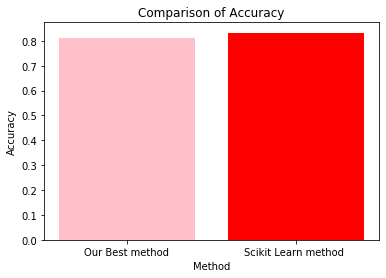

```python
import matplotlib.pyplot as plt
plt.subplot()
lable = ['Our Best method','Scikit Learn method ']
accuracy = [best, sk]
colors = ['pink', 'red']
plt.bar(lable, accuracy,color=colors)
plt.xlabel("Method")
plt.ylabel("Accuracy")
plt.title("Comparison of Accuracy")
```

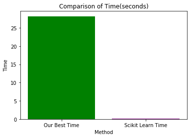

```python
plt.subplot()
lable = ['Our Best Time','Scikit Learn Time']
time = [28.2, 0.116]
colors = ['green', 'purple']
plt.bar(lable, time,color=colors)
plt.xlabel("Method")
plt.ylabel("Time")
plt.title("Comparison of Time(seconds)")
```

From the result we got before and the bar plot above, the time of Scikit Learn is way faster than our best time (with steepest descent)

# 3 Deployment

We would advise to use scikit-learn logistic regression to be used in a deployed machine learning model, because the implementation time of scikit-learn is way way shorter than our model, though the accuracy of scikit-learn is only a little bit higher than ours.

The most important reason that we recommend you to use scikit-learn is that if you use our own model,it's a little bit of arduous for you to find the best optimazation method and the values of best regularization and best cost term. But if you use scikit-learn, it will have already given you the default wanted parameters, finally, implementing logistic regression model will be much faster and more accurate.

In conclusion, we recommend using scikit-learn implementation for deployment in a machine learning model.

Here we have a question why scikit-learn runs so fast?  
Accodeing to https://scikit-learn.org/stable/developers/performance.html (citation)  
In general, the scikit-learn project emphasizes the readability of the source code to make it easy for the project users to dive into the source code so as to understand how the algorithm behaves on their data but also for ease of maintainability (by the developers). When implementing a new algorithm is thus recommended to start implementing it in Python using Numpy and Scipy by taking care of avoiding looping code using the vectorized idioms of those libraries. In practice this means trying to replace any nested for loops by calls to equivalent Numpy array methods. The goal is to avoid the CPU wasting time in the Python interpreter rather than crunching numbers to fit your statistical model.

# 4 Exceptional Work

We reload our data to do both multiple logistic regression and binary logistic regression.

#### Multiple-class train and test dataset

```python
#df = pd.read_csv("/Users/terrence/Desktop/train.csv")
df = pd.read_csv("/Users/chenqinyu/Desktop/mobile.csv")
#df = pd.read_csv(r"C:\Users\tony\Dropbox\smu\CSE7324\assignment\LabThree\train.csv")

X1 = df.iloc[:, :20].values
y1 = (df.iloc[:, 20]).astype(np.int).values
```

```python
from sklearn.model_selection import train_test_split

stdsc = StandardScaler()
X_train1, X_test1, y_train1, y_test1 = train_test_split(X1, y1, test_size=0.2, random_state=0, stratify=y1)
X_train1 = stdsc.fit_transform(X_train1)
X_test1 = stdsc.transform(X_test1)
```

#### Binary-class train and test dataset

```python
#df = pd.read_csv("/Users/terrence/Desktop/train.csv")
df = pd.read_csv("/Users/chenqinyu/Desktop/mobile.csv")
#df = pd.read_csv(r"C:\Users\tony\Dropbox\smu\CSE7324\assignment\LabThree\train.csv")
X2 = df.iloc[:, :20].values
y2 = (df.iloc[:, 20]>1).astype(np.int).values
```

```python
stdsc = StandardScaler()
X_train2, X_test2, y_train2, y_test2 = train_test_split(X2, y2, test_size=0.2, random_state=0, stratify=y2)
X_train2 = stdsc.fit_transform(X_train2)
X_test2 = stdsc.transform(X_test2)
```

## 4.1 Update the code to use either "one-versus-all" or "one-versus-one" extensions of binary to multi-class classification.

In this part, we defined a new function called "AutoLogisticRegression" which can auto distinguish binary class and multiple class. We add "if else" function to achieve this function.

```python
#combine codes from class codes
#codes cite from our class codes:https://github.com/eclarson/MachineLearningNotebooks/blob/master/06.%20Optimization.ipynb
class AutoLogisticRegression:
    ##  add a parameter called "method" to choose differet caculation function
    ##  defaulf using L2 regularization
    def __init__(self, eta, iterations=20,C2=1e-05 , method='steepest'):
        self.eta = eta
        self.iters = iterations
        self.C2 = C2
        self.method = method
        # internally we will store the weights as self.w_ to keep with sklearn conventions

    def __str__(self):
        if(hasattr(self,'w_')):
            return 'Auto Logistic Regression Object with coefficients:\n'+ str(self.w_)
        else:
            return 'Untrained Auto Logistic Regression Object'

    def fit(self,X,y):
        num_samples, num_features = X.shape
        self.unique_ = np.unique(y) # get each unique class value
        self.classifiers_ = [] # will fill this array with binary classifiers

        #one-versus-all
        if len(self.unique_)>2:
            print('multiple class, unique of target:',self.unique_)
            num_unique_classes = len(self.unique_)
            for i,yval in enumerate(self.unique_): # for each unique value
                y_binary = y==yval # create a binary problem
                # train the binary classifier for this class
                blr = L2Regularization(self.eta, self.iters, self.C2, self.method)
                blr.fit(X,y_binary)
                # add the trained classifier to the list
                self.classifiers_.append(blr)
            # save all the weights into one matrix, separate column for each class
            self.w_ = np.hstack([x.w_ for x in self.classifiers_]).T


        # one-versus-one
        else:
            print('binary class, unique of target:',self.unique_)
            blr = L2Regularization(self.eta, self.iters,self.C2, self.method)
            y_binary = y
            blr.fit(X,y_binary)
            self.classifiers_.append(blr)
            self.w_ = np.hstack([x.w_ for x in self.classifiers_]).T


    def predict_proba(self,X):
        probs = []
        for blr in self.classifiers_:
            probs.append(blr.predict_proba(X)) # get probability for each classifier

        return np.hstack(probs) # make into single matrix

    def predict(self,X):
        return np.argmax(self.predict_proba(X),axis=1) # take argmax along row
```

### One-versus-all

We tried y_train(4 class in target) to verify if AutoLogisticRegression can solve problems when it is multi-class.

```python
%%time

blr = AutoLogisticRegression(eta=0.1,iterations=1000,C2=1e-05)
blr.fit(X_train1,y_train1)
yhat1 = lr.predict(X_train1)
print('Accuracy of Training dataset: ',accuracy_score(y_train1,yhat1))
```

```
multiple class, unique of target: [0 1 2 3]
Accuracy of Training dataset:  0.843125
CPU times: user 2.92 s, sys: 25 ms, total: 2.94 s
Wall time: 743 ms
```

### One-versus-one

We tried y_new(binary) to verify if AutoLogisticRegression can solve problems when it is binary.

```python
%%time

blr = AutoLogisticRegression(eta=0.1,iterations=1000,C2=1e-05)
blr.fit(X_train2,y_train2)
yhat2 = lr.predict(X_train2)
print('Accuracy of Training dataset: ',accuracy_score(y_train2,yhat2))
```

```
binary class, unique of target: [0 1]
Accuracy of Training dataset:  0.313125
CPU times: user 759 ms, sys: 9.45 ms, total: 769 ms
Wall time: 196 ms
```

## 4.2 Implement an optimization technique for logistic regression using mean square error as your objective function

### The derivation process

The fomula comes from class github https://github.com/eclarson/MachineLearningNotebooks/blob/master/05.%20Logistic%20Regression.ipynb

mean square error objective function:

$$ l(\mathbf{w}) = \frac{1}{2}\sum_i \left( y^{(i)} -g( \mathbf{w}^T \mathbf{x}^{(i)}) \right)^2 $$

We can simplify this calculation a bit using matrix algebra to solve for the entire vector $w$:

$$ \mathbf{w} \leftarrow \mathbf{w} + \eta \underbrace{ \sum_{i=1}^M (y^{(i)}-g(\mathbf{w}^T\mathbf{x}^{(i)})) \cdot g(\mathbf{w}^T\mathbf{x}^{(i)})(1-g(\mathbf{w}^T\mathbf{x}^{(i)})) \mathbf{x}^{(i)} }_{\text{gradient}} $$

$$ \frac{\partial}{\partial \theta} g( \theta ) = g( \theta )(1-g( \theta )) $$$$ \frac{\partial}{\partial w} g( \mathbf{w}^T \mathbf{x}^{(i)} ) = g(\mathbf{w}^T\mathbf{x}^{(i)})(1-g(\mathbf{w}^T\mathbf{x}^{(i)})) \mathbf{x}^{(i)} $$$$ \frac{\partial}{\partial w} \mathbf{w}^T \mathbf{x}^{(i)} = \mathbf{x}^{(i)} $$

mean square error objective function: $N$ is the number of instances.
for our train data, N is 1600 $$ \ell (\mathbf{w}) = \frac{1}{2N}\sum_{i=1}^N \left( y^{(i)} -g( \mathbf{w}^T \mathbf{x}^{(i)}) \right)^2 $$

```python
#codes cite from our class codes:https://github.com/eclarson/MachineLearningNotebooks/blob/master/06.%20Optimization.ipynb
class MSEBinaryLogisticRegression:
    def __init__(self, eta, iterations=100, C=0.001):
        self.eta = eta
        self.iters = iterations
        self.C = C


    def __str__(self):
        if(hasattr(self,'w_')):
            return 'MSE Binary Logistic Regression Object with coefficients:\n'+ str(self.w_)
        else:
            return 'Untrained Binary Logistic Regression Object'

    # convenience, private:
    @staticmethod
    def _add_bias(X):
        return np.hstack((np.ones((X.shape[0],1)),X)) # add bias term

    @staticmethod
    def _sigmoid(theta):
        # increase stability, redefine sigmoid operation
        return expit(theta) #1/(1+np.exp(-theta))

    # vectorized gradient calculation with regularization using L2 Norm
    def _get_gradient(self,X,y):
        g = self.predict_proba(X,add_bias=False).ravel() # get sigmoid value for all classes
        hessian = X.T @ np.diag(g*(1-g)) @ X - 2 * self.C # calculate the hessian

        ydiff = y-g # get y difference
        gradient = (np.mean(X * (ydiff * g * (1-g))[:,np.newaxis], axis=0)) * 2 # make ydiff a column vector and multiply through
        gradient = gradient.reshape(self.w_.shape)
        gradient[1:] += -2 * self.w_[1:] * self.C

        return pinv(hessian) @ gradient

    # public:
    def predict_proba(self,X,add_bias=True):
        # add bias term if requested
        Xb = self._add_bias(X) if add_bias else X
        return self._sigmoid(Xb @ self.w_) # return the probability y=1

    def predict(self,X):
        return (self.predict_proba(X)>0.5) #return the actual prediction


    def fit(self, X, y):
        Xb = self._add_bias(X) # add bias term
        num_samples, num_features = Xb.shape

        self.w_ = np.zeros((num_features,1)) # init weight vector to zeros

            # for as many as the max iterations
        for _ in range(self.iters):
            gradient = self._get_gradient(Xb,y)
            self.w_ += gradient * self.eta # multiply by learning rate
```

### Solution should be able to solve the binary logistic regression problem in one update step.

```python
%%time
blr = MSEBinaryLogisticRegression(eta=0.1, iterations=100, C=0.001)

blr.fit(X_train2, y_train2)
yhat = blr.predict(X_test2)
print('Accuracy of: %.3f' % accuracy_score(y_test2, yhat))
```

```
Accuracy of: 0.950
CPU times: user 1.95 s, sys: 167 ms, total: 2.12 s
Wall time: 538 ms
```